# First steps with ‘fdagstat’

Ognjen Grujic & Alessandra Menafoglio

October 22, 2017

# The ‘fdagstat’ package

The `fdagstat` package is an expansion of the well-known `gstat` package by [Edzer Pebesma](https://cran.r-project.org/web/packages/gstat/). The package implements the recently developed trace-based based methods of functional geostatistics. In particular, it implements the ordinary-trace kriging method by [Giraldo et al (2011)](https://link.springer.com/article/10.1007/s10651-010-0143-y), universal trace kriging method by [Menafoglio et al (2013)](https://projecteuclid.org/euclid.ejs/1379596770), and universal trace-co-kriging method by [Grujic et al (2017)](https://www.doi.org/10.1007/s00477-017-1486-9). In the development of the package several applications were kept in mind:

1. Spatial or low dimensional interpolation of functional data as in [Giraldo et al (2011)](https://link.springer.com/article/10.1007/s10651-010-0143-y) and [Menafoglio et al (2013)](https://projecteuclid.org/euclid.ejs/1379596770)
2. High dimensional interpolation of single and multivariate functional data. One example of this application is functional-meta-modeling or multi-fidelity meta-modeling as outlined in [Grujic et al (2017)](https://www.doi.org/10.1007/s00477-017-1486-9)
3. Mixed interpolation by means of functional regression kriging where the drift term depends on several covariates and the functional residual is assumed to be spatially correlated.

In addition to the implemented trace-based routines, the package is also capable of scalar interpolation. In particular it implements universal and ordinary kriging and co-kriging methodologies ([Chiles and Delfiner (1999)](http://www.wiley.com/WileyCDA/WileyTitle/productCd-0470183152.html)). Therefore, the package is also capable of fitting functional principal component based methods of functional geostatistics such as: universal co-kriging of fpc scores by [Menafoglio et al (2016)](http://www.sciencedirect.com/science/article/pii/S2211675315001141) and universal co-kriging of fpc scores of multivariate functional data by [Bohorquez et al (2016)](http://dx.doi.org/10.1007/s00477-016-1266-y).

All routines contained in the package were developed for efficient practical and scientific usage. For example, our predict routine always exports kriging weights which was not the case in the original `gstat` implementation. Additionally, we use basic data structures such as lists, matrices and vectors for easy access and even easier edit/modification of all modeling parameters.

In this document we demonstrate the capabilities of the package by constructing two very basic functional meta-models. The functional data used in this tutorial were generated with a subsurface flow simulator (SLB Eclipse) by varying three input parameters. A detailed description of the subsurface model can be found in [Grujic et al (2017)](https://www.doi.org/10.1007/s00477-017-1486-9).

The data set used and analyzed in this tutorial is freely available and it is provided within the package (`data("3ParamFWPR")`).

# Universal Trace Kriging (UTrK).

In this tutorial we construct a functional meta-model with the universal trace-kriging methodology by [Menafoglio et al (2013)](https://projecteuclid.org/euclid.ejs/1379596770). We start with a brief data mining of the `3ParamFWPR` dataset provided within the `fdagstat` package. In figure below, we plot the “input” space spanned by the parameters that were varied as a part of the numerical simulation experiment. The right panel of the figure below represents all of the available functional data originally produced by the reservoir simulator and pre-processed through simple data transformation (for details see [Grujic et al (2017)](https://www.doi.org/10.1007/s00477-017-1486-9)).

```r
library(fdagstat)
data("3ParamFWPR")
```

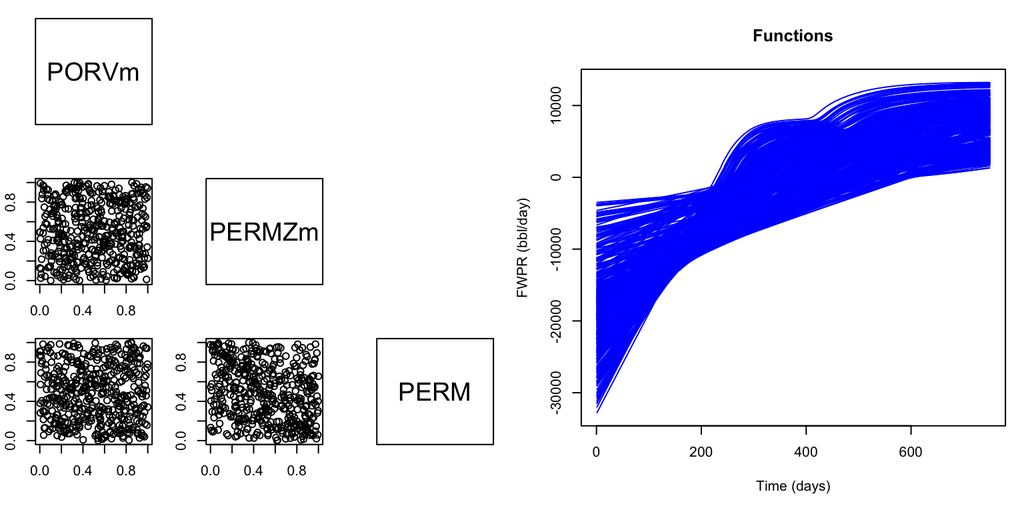

Left: Input space spanned by three parameters. Right: Functional output data

The input space was generated with random latin hypercube sampling, hence the input parameters are uncorrelated. In this analysis, the parameters are considered as fixed non-random objects. As a part of the pre-processing, all input parameters were scaled to [0,1], following a common practice in meta-modeling (see [Sacks et al (1989)](http://www.stat.osu.edu/~comp_exp/jour.club/Sacks89.pdf)).

Next we split the dataset into training and testing subsets, and proceed to fit a universal trace-kriging model, following [Menafoglio et al (2013)](https://projecteuclid.org/euclid.ejs/1379596770).

```r
set.seed(0)
train <- sample(nrow(DOE), floor(0.7*nrow(DOE)), replace = FALSE)
```

## Initialization

The first step with the `fdagstat` package is to create an `fstat` data structure, which is a simple `R` list. This is accomplished with the `fstat` function. This function is analogous to the `gstat` function from the `gstat` package.

```r
g <- fstat(NULL, vName = "FWPR", Coordinates = DOE[train,], Functions = Functions[,train], scalar = FALSE)
```

Here, the first input to the `fstat` function is `NULL` since we are initializing a new `fstat` data structure. The second parameter is the `variable name`. The assigned `variable name` will be used in all subroutines when processing the data. For example, the titles in variogram plots will correspond to the `variable name` assigned during the `fstat` data initialization phase. The third parameter is a data frame that contains the coordinates of the data, each row corresponding to a data point. In the presence of covariates to be considered in the drift linear model, these should be included as additional columns of the same data frame of coordinates. The fourth parameter is a data frame containing the evaluation of the functional data on an equispaced grid of arbitrary step. Here, each column of the data frame corresponds to a data point, each row to a value of the abscissa along which the data are evaluated. Hence, the number of rows in the `Coordinates` object must be equal to the number of columns in the `Functions` object. The fifth parameter `scalar` is a boolean variable which specifies the type of the fourth parameter. By default, it is set to `FALSE` meaning a functional response variable, as in this case. When set to `TRUE` the code will expect a column vector for the fourth parameter and all subsequently called geostatistical routines will work in scalar or conventional geostatistics mode.

## Drift Estimation

Next we estimate the functional drift and compute the functional residuals.

```r
g <- estimateDrift("~.", g, Intercept = TRUE)
```

## Trace Variogram Estimation

Our next step is to compute the trace variogram on the functional residuals. This is accomplished with the `fvariogram` function as follows

```r
g <- fvariogram("~.", g, Nlags = 100, LagMax = 1, ArgStep = 1, useResidual = TRUE, comments=FALSE)
```

The first input parameter is a formula specifying which columns of the `Coordinates` object should be used to compute the distances in variogram computations. For our meta-model, we consider as formula for variogram computation the same as the formula used for the drift computation. The second parameter is the `fstat` structure that contains the data and the drift object. Note that in stationary cases one can skip drift modeling and proceed directly to variogram computation with the `fvariogram` function. In that case the code would simply compute the variograms on the raw data. The third parameter `Nlags` specifies the number of spatial lags to be used for variogram computation. The fourth parameter `LagMax` represents the maximum distance among pairs of data according to which computing the empirical trace variogram. The fifth parameter specifies the sampling step of the `Functions` object provided upon `fstat` structure initialization. This parameter is important because the code is using the trapezoidal rule to compute the integrals in trace variogram computation. Finally, the sixth parameter specifies whether to use the residuals for variogram computation or the data themselves. Note that, in case of stationarity, this choice is not influential on the analysis. However, in the presence of non-stationarity, the trace-variogram estimated from the data may result in severely biased estimates.

In this example, we are suppressing the comments with the `comments=FALSE` flag.

Once the variogram computation is complete we can visualize the variogram with the following function:

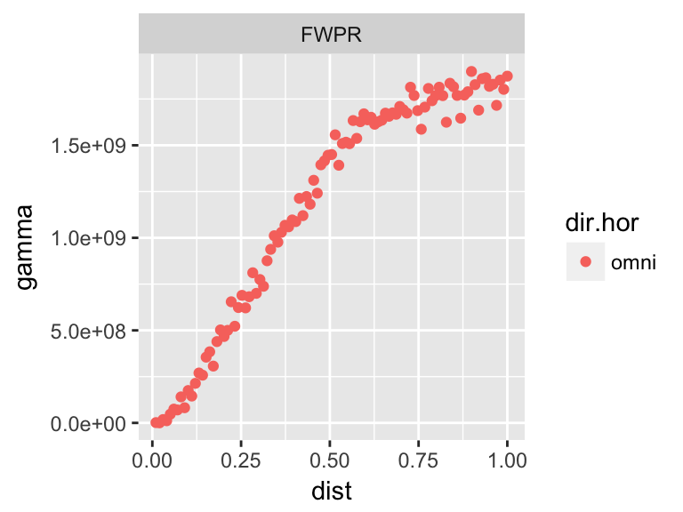

Empirical trace variogram

```r
plotVariogram(g)
```

Note that the `plotVariogram` function uses the `ggplot2` package routines for plotting. The function also has the capabilities to directly incorporate a pre-defined `ggplot2` theme or even to return a `ggplot2` object that can be further modified with the `ggplot2` commands. For more info please check out the `help(plotVariogram)` page, and see below for a few examples.

### Black

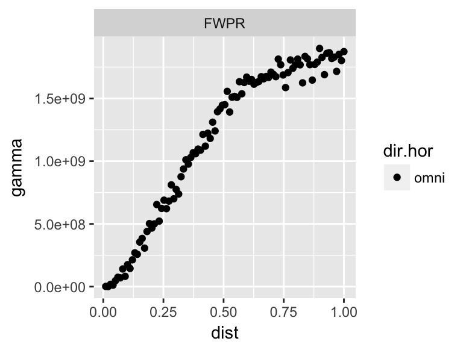

```r
print(plotVariogram(g, ggReturn = TRUE) + scale_colour_manual(values=c("black")))
```

### Orange Black

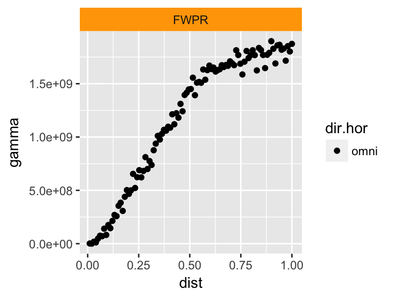

```r
print(plotVariogram(g, ggReturn = TRUE) + scale_colour_manual(values=c("black")) +  theme(strip.background = element_rect("orange")))
```

### Change Titles

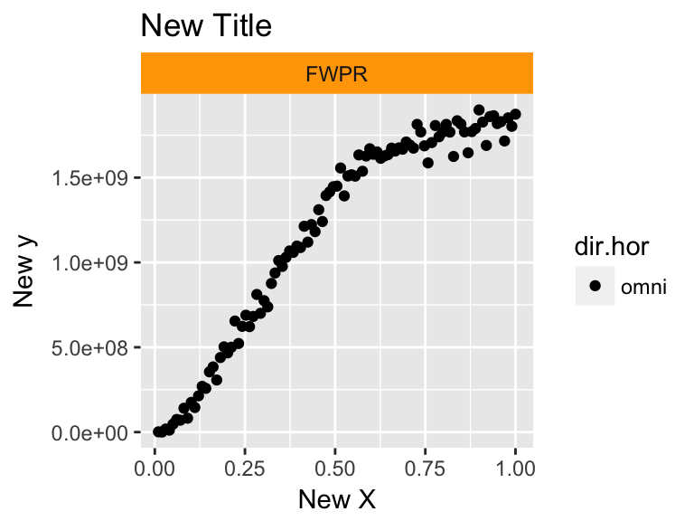

```r
print(plotVariogram(g, ggReturn = TRUE) + scale_colour_manual(values=c("black")) +  theme(strip.background = element_rect("orange")) + ggtitle("New Title") + xlab('New X') + ylab('New y'))
```

### Point Size

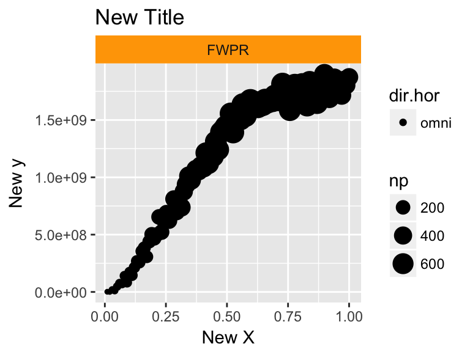

```r
print(plotVariogram(g, npSize = TRUE, ggReturn = TRUE) + scale_colour_manual(values=c("black")) +  theme(strip.background = element_rect("orange")) + ggtitle("New Title") + xlab('New X') + ylab('New y'))
```

The empirical variogram has a clear quadratic behavior at 0. Therefore, we proceed to fit a Gaussian model with the `fitVariograms` function.

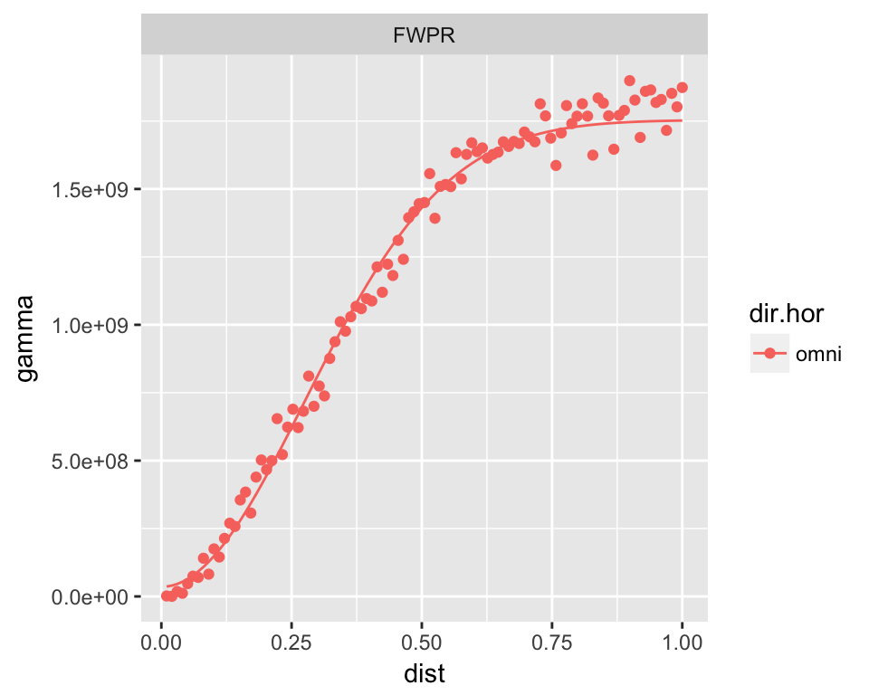

Fitted variogram

```r
g <- fitVariograms(g, model=vgm(2e+09, "Gau", 0.75, 0))
plotVariogram(g)
```

Finally, we proceed to use the fitted model to predict the functions of the test set. To this end, we first need to compute the covariance matrix between the training points. This can be achieved with the `addCovariance` function:

```r
g <- addCovariance(g, type = 'omni')
```

This will add a `covariance` slot to the `fstat` structure:

```r
str(g, 1)
```

```
## List of 6
##  $ data       :List of 1
##  $ variogram  :Classes 'gstatVariogram' and 'data.frame':    99 obs. of  7 variables:
##  $ model      :List of 1
##  $ drift      :List of 1
##   ..- attr(*, "type")= chr "OLS"
##   ..- attr(*, "formula")=List of 1
##  $ KrigFormula: chr "~."
##  $ covariance :List of 1
##   ..- attr(*, "covType")= chr "omni"
##  - attr(*, "class")= chr "fstat"
```

Note that the modeling workflow by [Menafoglio et al (2013)](https://projecteuclid.org/euclid.ejs/1379596770) considers drifts estimated with generalized least squares (GLS), through an iterative algorithm. The package has the capabilities to accomplish this. Before we describe the procedure, it is important to note that prior to fitting a GLS model one needs an estimate of an initial covariance matrix. This can be obtained as in the previous steps. That is, first the drift is estimated via ordinary least squares (`estimateDrift` function), second the trace-variogram is estimated empirically from the residuals (`fvariogram` function), then a valid model is fitted (`fitVariograms` function) and a covariance matrix is added (`addCovariance` function). To obtain the GLS estimate of the residuals, one is left to call the `estimateDrift` function one more time with `.type` set to `GLS`. In this case, the parameters of the model are estimated by using a generalized least square method, based on the current estimate of the covariance matrix. Given the new estimate of the drift, the variogram modeling is to be repeated as before from the updated residuals.

```r
g <- estimateDrift("~.", g, .type = "GLS", Intercept = TRUE)
g <- fvariogram("~.", g, Nlags = 100, LagMax = 1, ArgStep = 1, useResidual = TRUE, comments=FALSE)
g <- addCovariance(g, 'omni')
```

```r
g$model$omni$FWPR_pc1$psill <- g$model$omni$FWPR_pc1$psill/sum(g$model$omni$FWPR_pc1$psill)
g <- addCovariance(g)
```

Note that kriging is invariant by such kind of rescaling.

## Forecasting New Functions

To predict new data we use the `predictFstat` function:

```r
forecasts <- predictFstat(g, .newCoordinates = DOE[-train, ], .what = "FWPR", .type = "UK")
```

The first input to the function is the `fstat` structure that contains the model and the pre-computed covariance structure. The second input is a data frame with the coordinates of the target points. Note that the value at target points of possible covariates should be provided as columns in the `.newCoordinates` argument. The variables inside the provided `.newCooordinates` object must be the same as the ones provided inside the `.Coordinates` object upon the `fstat` structure initialization. The third input parameter specifies which variable to predict. The name of the target response must match one of the variable names provided during the `fstat` structure initialization phase. Finally, the fourth argument specifies which type of kriging the user wants to perform. Possible options for single variate functional data are `OK` or `UK` specifying ordinary trace-kriging by [Giraldo et al (2011)](https://link.springer.com/article/10.1007/s10651-010-0143-y), and universal trace kriging by [Menafoglio et al (2013)](https://projecteuclid.org/euclid.ejs/1379596770), respectively. The object returned by the `predictFstat` function is a list with the following slots:

```r
str(forecasts, 1)
```

```
## List of 5
##  $ C       : num [1:323, 1:323] 1.75e+09 4.69e+08 7.95e+07 2.38e+08 5.82e+06 ...
##   ..- attr(*, "sill")= num 1.75e+09
##  $ c       : num [1:323, 1:139] 8.21e+08 7.73e+08 9.38e+07 1.62e+07 3.09e+06 ...
##  $ Variance: num [1:139] 54792251 60290402 48610804 41949969 45166585 ...
##  $ Forecast: num [1:750, 1:139] -27275 -27169 -27063 -26958 -26852 ...
##  $ Weights : num [1:323, 1:139] -0.044 -0.02381 -0.00466 -0.00709 0.00184 ...
```

We plot the forecasted functions with the following code:

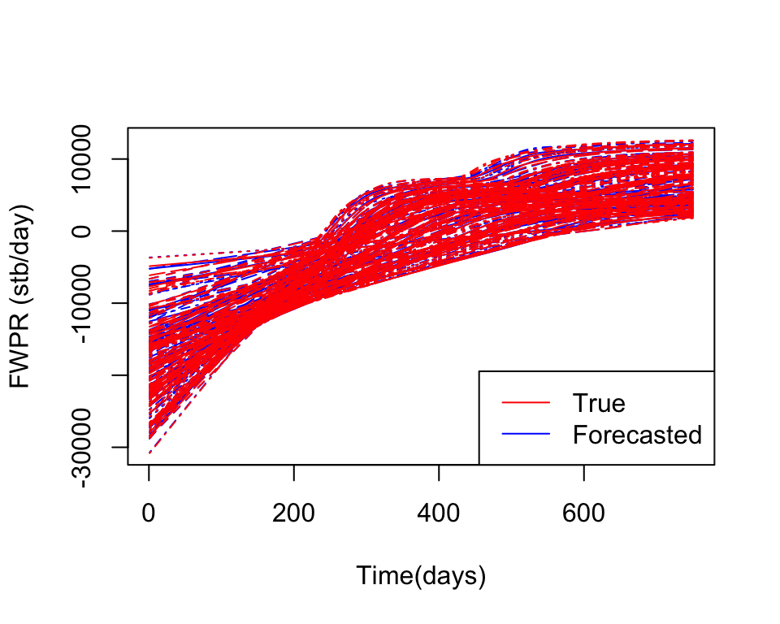

```r
matplot(forecasts$Forecast, type = "l", col="blue", xlab="Time(days)", ylab="FWPR (stb/day)")
matplot(Functions[,-train], type="l", col="red", add = TRUE)
legend('bottomright', c("True", "Forecasted"), col=c("red","blue"), lty=1, lwd=1)
```

# Universal Co-Kriging of Functional Principal Component Scores (UCoK)

An alternative approach to universal trace kriging was outlined in [Menafoglio et al (2016)](http://www.sciencedirect.com/science/article/pii/S2211675315001141), as a generalization of the stationary approach by [Nerini et al (2010)](http://www.sciencedirect.com/science/article/pii/S0047259X0900061X). The method starts by representing the functional data through a multivariate vector (i.e., scores), by using functional principal component analysis. The method then proceeds to build a universal co-kriging predictor on these scores and to forecast functional data at unobserved locations or design points via their predicted scores. The `fdagstat` has the capability of fitting such models, as we demonstrate next.

## Functional Data Analysis

We start by performing functional principal component analysis of the training set. Here we choose to work with the first two functional principal components since they described more than 95% of the variance in the data.

```r
library(fda)
basis <- create.bspline.basis(c(1,750), 30, 4)
expandedFunctions <- smooth.basis(1:750, as.matrix(Functions[,train]), basis)
expandedFunctions.pca <- pca.fd(expandedFunctions$fd, 2)
MEAN <- eval.fd(1:750, expandedFunctions.pca$meanfd)
FPCS <- eval.fd(1:750, expandedFunctions.pca$harmonics)
```

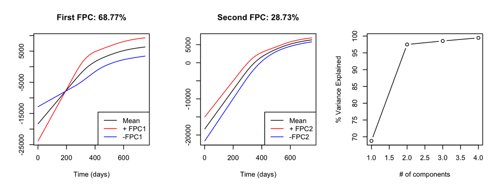

FPCA Results

Note that one may resort to numerical routines to perform functional principal component analysis, without operating a projection over a functional basis as we considered here. In the following, for illustrative purposes, we will work with standardized functional principal component scores. This is mainly due to the fact that the Linear Model of Coregionalization (LMC, [Goovaerts (1993)](https://books.google.com/books/about/Geostatistics_for_Natural_Resources_Eval.html?id=CW-7tHAaVR0C)) is often easier to fit when all variables are expressed on the same scale.

```r
sd1 <- sd(expandedFunctions.pca$scores[,1])
mn1 <- mean( expandedFunctions.pca$scores[,1])
sd2 <- sd(expandedFunctions.pca$scores[,2])
mn2 <- mean( expandedFunctions.pca$scores[,2])

FPWR_pc1 <- (expandedFunctions.pca$scores[,1] - mn1)/sd1
FPWR_pc2 <- (expandedFunctions.pca$scores[,2] - mn2)/sd2
```

In this case, to recover the original scale, one need to operate a back-scaling after prediction, before building the functional prediction, as we show below.

## Initialization and Variogram Fitting

The initialization of the `fstat` object is performed in the same way as before, except for the argument `scalar`, which now needs to be set to `scalar=TRUE` to indicate that we are working with scalar data.

```r
g <- fstat(NULL, 'FWPR_pc1', DOE[train,], as.data.frame(FPWR_pc1), scalar=TRUE)
g <- fstat(g, 'FWPR_pc2', DOE[train,], as.data.frame(FPWR_pc2), scalar=TRUE)
```

The rest of the modeling methodology is analogous to the universal trace kriging workflow presented earlier:

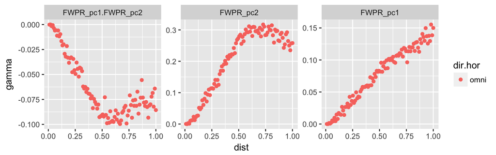

Variograms of the fpc scores

```r
g <- estimateDrift("~.", g, Intercept = TRUE)
g <- fvariogram("~.", g, Nlags = 100, LagMax = 1,
                useResidual = TRUE, comments=FALSE)
plotVariogram(g)
```

Note that in this case we have three variograms. Two omni-directional auto variograms (`FWPR_pc1` and `FWPR_pc1`), and one cross variogram (`FWPR_pc1.FWPR_pc2`). To fit the three variograms we use the linear model of coregionalization (LMC, Goovaerts (1993)). In the `gstat` package this is accomplished with the `fit.lmc` function that is called in the backend of `fitVariograms`. Since the `fit.lmc` function allows for variable ranges in the variograms which violates the assumption of the linear model of coregionalizaiton, here, we set `fitRanges` to `FALSE` to fit a numerically valid model. Hence, the ranges are not optimized, but kept fixed to their initial values.

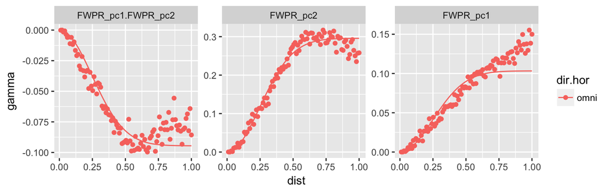

Fitted variogram models

```r
g <- fitVariograms(g, model = vgm(0.3, "Gau", 0.35, 0), forceNugget = TRUE, fitRanges = FALSE)
plotVariogram(g)
```

```r
g <- addCovariance(g, 'omni')
```

Future versions of the package will contain improved codes for LMC fitting, that will perform a more advanced and more flexible multivariate model fitting.

## Forecasting New Functions

Forecasting is analogous to the universal trace kriging example shown before.

```r
forecast.pc1 <- predictFstat(g, .newCoordinates = DOE[-train,], .what = "FWPR_pc1", .type = "UcoK", algIndependent = TRUE)
forecast.pc2 <- predictFstat(g, .newCoordinates = DOE[-train,], .what = "FWPR_pc2", .type = "UcoK", algIndependent = TRUE)
```

Note that in this case the `predictFstat` function is called twice, since both the scores needs to be predicted to reconstruct the function. Moreover, we are using universal co-kriging (`.type="UcoK"`) with algebraically independent drifts (`algIndependent = TRUE`). Readers who are not familiar with different types of co-kriging are can refer to Chiles and Delfiner (1999).

Finally, we use the forecasted principal component scores to construct the forecasts of unobserved functions. The following code achieves this, and plots the results.

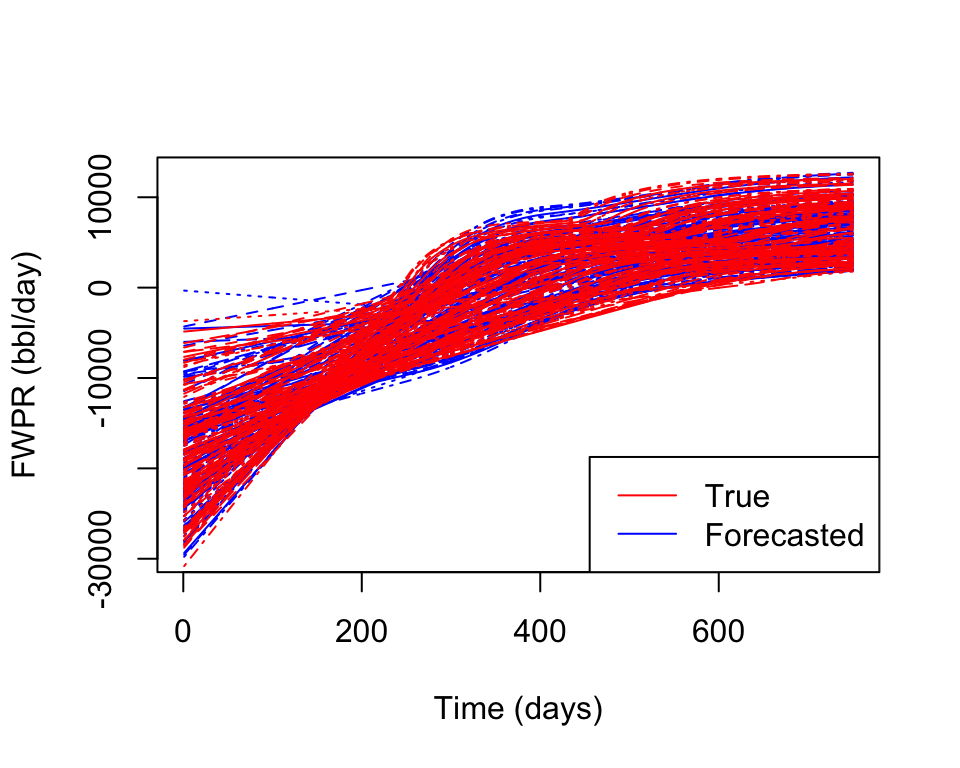

UCoK forecasts

```r
# Bring back to the original scale:
forecast.pc1$Forecast <- (forecast.pc1$Forecast * sd1) + mn1
forecast.pc2$Forecast <- (forecast.pc2$Forecast * sd2) + mn2

# Construct functions:
forecast <- NULL
for(i in 1:length(forecast.pc1$Forecast)){
  forecast <- rbind(forecast, t(MEAN + FPCS %*% c(forecast.pc1$Forecast[i], forecast.pc2$Forecast[i])))
}
matplot(t(forecast), type="l", col="blue", xlab="Time (days)", ylab="FWPR (bbl/day)")
matplot(Functions[,-train], type = "l", col="red", add=TRUE)
legend('bottomright', c("True", "Forecasted"), lty=1, col=c("red", "blue"))
```